# exercise-09

2024-03-06

## Step 1

This exercise is working with the published dataset from Street et al. (2017).

```r
library(tidyverse)
library(dplyr)
library(skimr) #To use the skim() function
f <- "https://raw.githubusercontent.com/difiore/ada-2024-datasets/main/Street_et_al_2017.csv"
(d <- read_csv(f,col_names = TRUE)) #As a tibble, d
```

```
## # A tibble: 301 × 13
##    Species      Taxonomic_group Social_learning Research_effort   ECV Group_size
##    <chr>        <chr>                     <dbl>           <dbl> <dbl>      <dbl>
##  1 Allenopithe… Catarrhini                    0               6  58.0       40
##  2 Allocebus_t… Catarrhini                    0               6  NA          1
##  3 Alouatta_be… Platyrrhini                   0              15  52.8        7.4
##  4 Alouatta_ca… Platyrrhini                   0              45  52.6        8.9
##  5 Alouatta_gu… Platyrrhini                   0              37  51.7        7.4
##  6 Alouatta_pa… Platyrrhini                   3              79  49.9       13.1
##  7 Alouatta_pi… Platyrrhini                   0              25  51.1        5.5
##  8 Alouatta_sa… Platyrrhini                   0               4  59.1       NA
##  9 Alouatta_se… Platyrrhini                   0              82  55.2        7.9
## 10 Aotus_azarai Platyrrhini                   0              22  20.7        4.1
## # ℹ 291 more rows
## # ℹ 7 more variables: Gestation <dbl>, Weaning <dbl>, Longevity <dbl>,
## #   Sex_maturity <dbl>, Body_mass <dbl>, Maternal_investment <dbl>,
## #   Repro_lifespan <dbl>
```

To generate the five-number summary (median, minimum and maximum and 1st and 3rd quartile values), plus mean and standard deviation, for each quantitative variable, I am using the skim() function from {skimr}.

```r
skimd <- skim(d) |>
  filter(skim_type == "numeric") |>
  select(skim_type, skim_variable, numeric.p50, numeric.p0, numeric.p100, numeric.p25, numeric.p75, numeric.mean, numeric.sd)

names(skimd)[names(skimd) == "numeric.p50"] <- "median"
names(skimd)[names(skimd) == "numeric.p0"] <- "minimum"
names(skimd)[names(skimd) == "numeric.p100"] <- "maximum"
names(skimd)[names(skimd) == "numeric.p25"] <- "Q1"
names(skimd)[names(skimd) == "numeric.p75"] <- "Q3"
names(skimd)[names(skimd) == "numeric.mean"] <- "mean"
names(skimd)[names(skimd) == "numeric.sd"] <- "sd"

(as.tibble(skimd))
```

```
## # A tibble: 11 × 9
##    skim_type skim_variable    median minimum maximum     Q1     Q3   mean     sd
##    <chr>     <chr>             <dbl>   <dbl>   <dbl>  <dbl>  <dbl>  <dbl>  <dbl>
##  1 numeric   Social_learning     0      0     2.14e2 0      0      2.30e0 1.65e1
##  2 numeric   Research_effort    16      1     7.55e2 6   e0 3.77e1 3.88e1 8.06e1
##  3 numeric   ECV                58.6    1.63  4.91e2 1.18e1 8.62e1 6.85e1 8.28e1
##  4 numeric   Group_size          7.5    1     9.12e1 3.12e0 1.82e1 1.33e1 1.52e1
##  5 numeric   Gestation         166.    60.0   2.75e2 1.38e2 1.83e2 1.65e2 3.80e1
##  6 numeric   Weaning           234.    40     1.26e3 1.22e2 3.89e2 3.11e2 2.53e2
##  7 numeric   Longevity         301.   103     1.47e3 2.16e2 3.93e2 3.32e2 1.66e2
##  8 numeric   Sex_maturity     1427.   283.    5.58e3 7.02e2 1.89e3 1.48e3 9.99e2
##  9 numeric   Body_mass        3554.    31.2   1.3 e5 7.39e2 7.46e3 6.80e3 1.42e4
## 10 numeric   Maternal_invest…  401.   100.    1.49e3 2.56e2 5.92e2 4.79e2 2.92e2
## 11 numeric   Repro_lifespan   8326.  2512.    3.91e4 6.13e3 1.07e4 9.06e3 4.60e3
```

## Step 2

Plotting **brain size (ECV)** as a function of **social group size (Group_size)**:

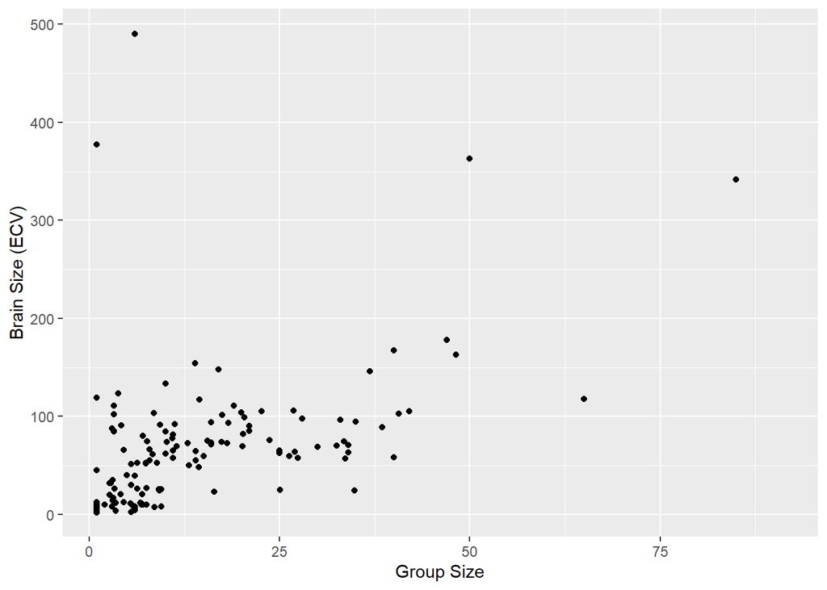

```r
(p1 <- ggplot(data = d, aes(x = Group_size, y = ECV)) +
   xlab("Group Size") +
   ylab("Brain Size (ECV)")+
   geom_point(na.rm = TRUE))
```

Plotting **brain size (ECV)** as a function of **longevity (Longevity)**:

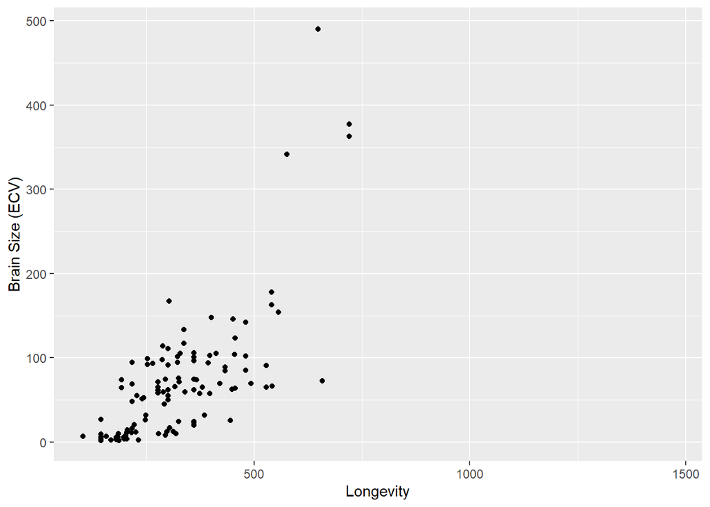

```r
(p2 <- ggplot(data = d, aes(x = Longevity, y = ECV)) +
   xlab("Longevity") +
   ylab("Brain Size (ECV)") +
   geom_point(na.rm = TRUE))
```

Plotting **brain size (ECV)** as a function of **juvenile period length (Weaning)**:

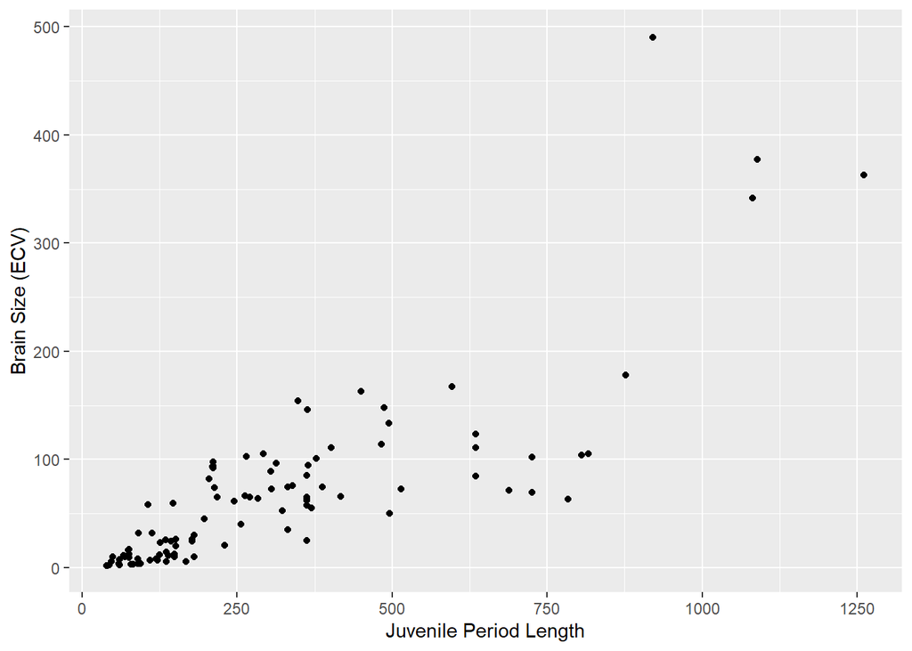

```r
(p3 <- ggplot(data = d, aes(x = Weaning, y = ECV)) +
   xlab("Juvenile Period Length") +
   ylab("Brain Size (ECV)")+
   geom_point(na.rm = TRUE))
```

Plotting **brain size (ECV)** as a function of **reproductive lifespan (Repro_lifespan)**:

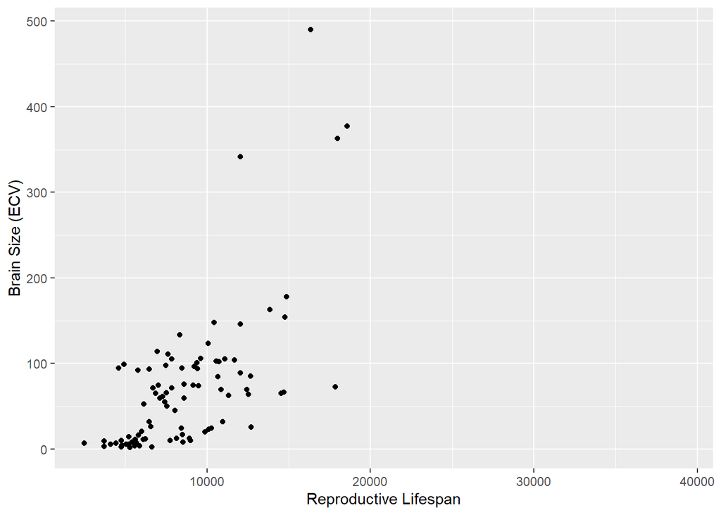

```r
(p4 <- ggplot(data = d, aes(x = Repro_lifespan, y = ECV)) +
   xlab("Reproductive Lifespan") +
   ylab("Brain Size (ECV)")+
   geom_point(na.rm = TRUE))
```

## Step 3

Deriving the ordinary least squares regression coefficients, β1 and β0, for ECV as a function of social group size:

Note: β1 = cov(x,y)/var(x)) β0 = mean(y) - β1*(mean(x))

```r
d2 <- d |> drop_na("ECV","Group_size")

(β1 <- cov(d2$Group_size,d2$ECV)/var(d2$Group_size))
```

```
## [1] 2.463071
```

```r
(β0 <- mean(d2$ECV) - β1 * mean(d2$Group_size))
```

```
## [1] 30.35652
```

## Step 4

Now, I can check my β1 and β0 derived in **Step 3** using the lm() function:

```r
(lm(ECV ~ Group_size, data = d2))
```

```
##
## Call:
## lm(formula = ECV ~ Group_size, data = d2)
##
## Coefficients:
## (Intercept)   Group_size
##      30.357        2.463
```

The regression coefficients returned by lm() match those derived in **Step 3**.

## Step 5

### Repeating the above analysis for catarrhines only:

Repeating **Step 3** for catarrhines only:

```r
catarrhines <- d2 |> filter(Taxonomic_group == "Catarrhini")

(cβ1 <- cov(catarrhines$Group_size,catarrhines$ECV)/var(catarrhines$Group_size))
```

```
## [1] 1.146322
```

```r
(cβ0 <- mean(catarrhines$ECV) - cβ1 * mean(catarrhines$Group_size))
```

```
## [1] 83.42059
```

Repeating **Step 4** for catarrhines only:

```r
(lm(ECV ~ Group_size, data = catarrhines))
```

```
##
## Call:
## lm(formula = ECV ~ Group_size, data = catarrhines)
##
## Coefficients:
## (Intercept)   Group_size
##      83.421        1.146
```

### Repeating the above analysis for platyrrhines only:

Repeating **Step 3** for platyrrhines only:

```r
platyrrhines <- d2 |> filter(Taxonomic_group == "Platyrrhini")

(pβ1 <- cov(platyrrhines$Group_size,platyrrhines$ECV)/var(platyrrhines$Group_size))
```

```
## [1] 1.965176
```

```r
(pβ0 <- mean(platyrrhines$ECV) - pβ1 * mean(platyrrhines$Group_size))
```

```
## [1] 16.18121
```

Repeating **Step 4** for platyrrhines only:

```r
(lm(ECV ~ Group_size, data = platyrrhines))
```

```
##
## Call:
## lm(formula = ECV ~ Group_size, data = platyrrhines)
##
## Coefficients:
## (Intercept)   Group_size
##      16.181        1.965
```

### Repeating the above analysis for strepsirhines only:

Repeating **Step 3** for strepsirhines only:

```r
strepsirhines <- d2 |> filter(Taxonomic_group == "Strepsirhini")

(sβ1 <- cov(strepsirhines$Group_size,strepsirhines$ECV)/var(strepsirhines$Group_size))
```

```
## [1] 1.840664
```

```r
(sβ0 <- mean(strepsirhines$ECV) - sβ1 * mean(strepsirhines$Group_size))
```

```
## [1] 8.176384
```

Repeating **Step 4** for strepsirhines only:

```r
(lm(ECV ~ Group_size, data = strepsirhines))
```

```
##
## Call:
## lm(formula = ECV ~ Group_size, data = strepsirhines)
##
## Coefficients:
## (Intercept)   Group_size
##       8.176        1.841
```

Looking at these values sides by side…

```r
group <- as.tibble(c("Catarrhines","Platyrrhines","Strepsirhines"))
names(group)[names(group) == "value"] <- "Taxonomic Group"
beta1 <- as.tibble(c(cβ1,pβ1,sβ1))
names(beta1)[names(beta1) == "value"] <- "β1"
beta0 <- as.tibble(c(cβ0,pβ0,sβ0))
names(beta0)[names(beta0) == "value"] <- "β0"

(compare <- bind_cols(group,beta1,beta0))
```

```
## # A tibble: 3 × 3
##   `Taxonomic Group`    β1    β0
##   <chr>             <dbl> <dbl>
## 1 Catarrhines        1.15 83.4
## 2 Platyrrhines       1.97 16.2
## 3 Strepsirhines      1.84  8.18
```

The regression coefficients appear to differ among groups. One way to test this would be to use a permutation test to evaluate whether or not there was a statistically significant difference between the values.

```r
#Calculating the standard error for the slope coefficient:
m <- (lm(ECV ~ Group_size, data = d2))

SSE <- sum((m$residuals)^2)

SSX <- sum((m$model$Group_size-mean(m$model$Group_size))^2)

MSE <- SSE/(nrow(d2)-2)

(seβ1 <- sqrt(MSE/SSX))
```

```
## [1] 0.3508061
```

```r
#Calculating the 95% CI:
```

[output not shown]

```r
#Calculating the p-value:
```

[output not shown]

Checking these calculations by extracting the same information from the results of the lm() function:

```r
library(broom)
(tidy(m))
```

```
## # A tibble: 2 × 5
##   term        estimate std.error statistic  p.value
##   <chr>          <dbl>     <dbl>     <dbl>    <dbl>
## 1 (Intercept)    30.4      6.80       4.47 1.56e- 5
## 2 Group_size      2.46     0.351      7.02 7.26e-11
```

```r
(confint(m,"Group_size",level=0.95))
```

```
##               2.5 %   97.5 %
## Group_size 1.769874 3.156269
```

The seβ1 is 0.3508, which matches the seβ1 I calculated by hand. The 95% CI is [1.769874,3.156269]. The p-value is 7.259e-11.